# Metagenomic’s Logbook

Jarno Jacob Duiker

Compiled on: 04 April, 2025

# Tools

For more indepth explenation of the tools, look at the logbook of Yamila and or Floris.

| Package Name | Description | Version |
| --- | --- | --- |
| [Kraken2](https://github.com/DerrickWood/kraken2) | Taxonomic classification of 16S data | 2.1.3 |
| Bracken | Re-estimating abundances from Kraken2 output | 3.0.1 |
| Krona | Visualising taxonomic classification in a sample | 2.8.1 |
| kraken-biom | Converting kraken file to json formatted .biom | 1.2.0 |
| [FAPROTAX](http://www.loucalab.com/archive/FAPROTAX/lib/php/index.php?section=Home) | Functional analysis for finding (metabolic) pathways that match the founc OTU’s | 1.2.10 |
| Github | Cloud-based Git repository hosting service |  |
| Git | Version control system for tracking changes in code | 2.44.0 |
| Snakemake | Workflow management system for reproducible data analyses | 9.1.5 |
| Rstudio | IDE for R with an enhanced user interface | 2023.12.1+402 |
| R | Statistical computing and graphics language | R version 4.4.1 (2024-06-14) – “Race for Your Life” |
| Python | General-purpose programming language for data science and bioinformatics | 3.12 |

# Introduction

For this metagenomics project our group was asked to look what microbial community lives in the waste water from a Molasses-Based Spirit and Yeast Production Factory. The waste water samples we’re taken from 3 stages. The waste water straight from the factory, within the digester (a closed container utilising anaerobic bacteria to break down organic material and produce methane) and from the exit of the lagoon where the water flows back into the river. These samples we’re sequenced with minION but due to a problem with it’s flowcell our digester sample turned out bad. Therefore we have chosen to no include it in this research. Using Snakemake we created a pipeline that trims and checks the sample quality. this was done using `Fastplong` OpenGene (n.d.), Then the data was ran through a tool called `Kraken2` D. E. Wood, Lu, and Langmead (2019) this is a computational tool for microbial classification. This gave kreports (kraken reports) and kraken.out files that were used to make visualizations. `Kronatools` Ondov, Bergman, and Phillippy (2011) was used to make some Krona charts, Krona visualises classification data in a multi-layered pie chart. These charts are interactive and can be viewed within a webbrowser Kaufman (2024) The visualisation that follows from using this tool could prove as a nice overview of the classification, for in our paper. (for more info look at Logbook - Yamila). Another visualisation that was used was a sankey plot, The custom Snakemake workflow for generating taxonomic Sankey charts was developed with guidance from DeepSeek-R1-Lite-Preview, a large language model DeepSeek (2024) . A functional analysys was then made with the Kraken2 output, The classified species were compared to the FAPROTAX database and from there certain (metabolic) pathways were found. This was key our functional analysis

## Research question

What Microbial Community live in an Anaerobic Reactor for the Treatment of Wastewater from a Molasses-Based Spirit and Yeast Production Factory

Goals: Find tools that will build our pipeline Find What our pipeline needs to do Write material and methods Clear up our question from our supervisor

# Logbook

## 4 march

**Goal of the day:**

Setting up a github project to devide the tasks among the team members

The tasks: Write materials - Jarno  
Write Methods - Jarno  
**Snakemake**  
Fastplong - Floris  
kraken2 - Yamila  
KronaTools - Yamila Funtional analysis tools (bubble plot / fastprotax) Floris  
Shannon index for alpha diversity + beta diversity- Jarno  
Presentation -conlusion and discussion needs to be written by everyone

## 6 march

**Goal of the day:**

First Version and back ground research for the materials and methods

### background info for the usage of the tools

**FastQC Quality control**  
FastQC is used to check the quality of raw data, determining if the data is ready for use or needs trimming. The trimmer can also be adjusted based on FastQC results. (**BabrahamBioinformatics?**)

We use FastQC to ensure the data is suitable for analysis. Poor-quality data can lead to unreliable and non-reproducible results.

Below is a breakdown of the results from a FastQC check and how to interpret them.

[output not shown]

This info was found on the fastqc website - Babraham Bioinformatics (n.d.)

**Trimmomatic - got turned into fastplong**

Trimmomatic s a versatile and robust tool for the processing of sequence data, proficient in managing both paired-end and single-end datasets. The software encompasses a series of trimming steps accompanied by an array of customizable parameters aimed at optimizing data quality. As a command-line application, Trimmomatic is especially advantageous for addressing complexities associated with the “collapsing” and “trimming” of paired-end reads, particularly in cases where sequencing fragments are shorter than the read length, which can lead to undesirable overlaps with adapter sequences present at the terminal ends of the reads. Ensuring data integrity during the cleaning process is a fundamental feature of Trimmomatic. The necessity of data trimming arises predominantly from the presence of low-quality sequence data. Enhancing data quality is critical, as the extraction of reliable conclusions is jeopardized by the prevalence of errors often associated with poor-quality inputs. Trimmomatic’s customizable framework allows for the efficient removal of adapter sequences, while also enabling specific adjustments tailored to the dataset in question.

**Taxonomische classificatie met Kraken 2**

Derrick E. Wood, Lu, and Langmead (2019b) D. E. Wood, Lu, and Langmead (2019)

Kraken 2 is a taxonomic classification system that uses k-mer matches to get high accuracy and fast classification speeds. A k-mer is a substring of length k contained within a biological sequence. Simply said, k-mers are simply length k subsequences. 1-k k-mers are G, T, A, C. 2-k k-mers are GT, TA, AG, GA, AG, GC, CT, TG, GT. Using the matching principle, kraken 2 doesn’t have to read the full sequence and can quickly determine whether a species matches or not.

Kraken 2 will read each sequence and match them to their complementary counterpart. Giving us the Taxonomy as far as is known for each microorganism. Helping understand what the water contains.

The output for kraken 2 is a single line of output with five tab-delimited fields; from left to right they are: “C”/”U”: a one letter code indicating that the sequence was either classified or unclassified, The sequence ID, obtained from the FASTA/FASTQ header. The taxonomy ID Kraken 2 used to label the sequence; this is zero if the sequence is unclassified. The length of the sequence is in base pairs. In the case of paired read data, this will be a string containing the lengths of the two sequences in bp, separated by a pipe character, e.g. “98|94”. Lastly, a space-delimited list indicating the LCA mapping (lowest common ancestor)

**Visualisations of the classification with Pavian** Pavian is an interactive browser application that analyzes and visualizes metagenomics classification results from classifiers such as Kraken, KrakenUniq, Kraken 2, Centrifuge, and MetaPhlAn. Pavian also provides an alignment viewer to validate matches to a particular genome. The seamless implementation with Kraken 2 makes this a good choice for visualisation. The visualisations that are made with Pavian are a taxonomic classification chart, a Sankey diagram, and an alignment viewer. Breitwieser and Salzberg (2020)

**Feedback** *Instead of reposting the old materials and methods i will only be putting down the feedback to prevent long re-reads.* - Use past tense and fix the dual use - Fix the issue about naming “pathogenic organisms in the lagoon” this is because we want to know what will flow in the river. Therefore we want to specifically know what kind of organisms live in the lagoon output, not the lagoon middle. - Make use of more commas and interpunctions in general. - Change the main focus from “dangerous microorganisms” to identifying the microbiome of the lagoon and a global overview of what lives in the three different steps + what they do. - Fix the following sentence “Using this, we were able to see the dangers and problems the microorganisms cause in the lagoon” this needs to be fixed because there arent problems within the lagoon the problem is what is exciting the lagoon into the river. - Explanation of the usage of BGP.

## 8 march

Second feedback on the materials and methods, This time from my team members and the teacher.

General feedback: Make an overall approach that quickly summarises your whole pipeline. Fix the over-quoting and remove the ones that aren’t necessary. Fix spelling isues and make sure the sentences are normal with an academic tone Add data collection tab that explains how the data was collected and in our case how it was sequenced + with what settings.

**9th of march** *This is the final version for now, it still is missin gour data collection due to not being emailed back about it yet.*

## 2. Materials and methods

#### 2.1 overal approach

The sequencing data obtained from the MinION platform underwent a quality assessment process. Initially, the sequences were evaluated for quality using `Fastplong` (OpenGene, 2023) (Chen et al., 2018). After this, `Fastplong` also trimmed the data according to the generated reports. Following this, a secondary quality assessment was conducted using `Fastplong` to ensure improved data quality. The refined dataset was then subjected to taxonomic classification through `Kraken2` (Wood et al., 2019), a computational tool for microbial classification. The results generated by `Kraken2` were then visualised using `KronaTools` (Ondov et al., 2011) and `Pavian` (Breitwieser & Salzberg, 2020), facilitating an interactive and intuitive representation of the taxonomic distribution. Other tools like `HUMAnN 3.0` (Beghini et al., 2021) were used for profiling the abundance of microbial metabolic pathways and other molecular functions from metagenomics data (Beghini et al., 2021). Furthermore, the outcomes obtained from the `Kraken2` analysis were employed to identify the microorganisms present in the lagoon water, this allowed comparing the different lagoon stages and their microbiomes. To get more insight into the data using `QIIME2` (Bolyen et al., 2019b), a tool that made a Shannon index for alpha diversity, this index showed the species diversity in each sample. This index also showed the distribution of the species in the samples. With all this information, an analysis for each stage of the lagoon has been made.

#### 2.2 Data collection

(added later) at this point it was still unknown

### 2.3 The metagenomics pipeline

#### 2.3.1 **Data Preprocessing and Quality Control**

Raw sequencing data has been received in the FASTQ format, this data was preprocessed using `fastplong` . A specialized version of the fastp tool optimised for Nanopore long-read data, adapter and low quality reads (Phred score < 20) were trimmed, and reads shorter than 50 bp were no longer used to ensure the high-quality and keep the data integrity high for the downstream analysis. After this first trim, the data was assessed to see if the data quality had improved again using `fastplong`. It was concluded that the data did not need more trimming, allowing the next step to proceed.

#### 2.3.2 Identifying microorganisms using taxonomic classification

The processed FASTQ files were run through the pipeline’s next step, `Kraken2`. `Kraken2` was used to get the taxonomic classification of each found microorganism. This was done by matching k-mer sequences (nucleotide sequences), giving `Kraken2` high accuracy. The output file has a certain structure with some important things like the taxonomy ID, whether a sequence was classified or not and a list containing the lowest common ancestor. The identities of the present microorganisms were revealed by their taxonomy ID, however, reading each ID and searching these up would be quite inefficient. This will be solved with the visualisation step, which takes these IDs and visualises them. Derrick E. Wood, Lu, and Langmead (2019b) D. E. Wood, Lu, and Langmead (2019)

#### 2.3.3 Visualisation of kraken2 results

To visualise what has been found from the Taxonomic classification of the `Kraken2` tool, we used a multitude of different tools, `KronaTools` was used to create krona plot, a krona plot shows all taxonomic levels based on the NCBI taxonomy starting from superkingdom to family level and the associated abundances based on the number of identified spectra summed over all BGPs (Bacterial Gene Product). This was used in the paper to show what had been found in an easy to interpret way. `Pavian` was used to create an interactive browser application that analysed and visualised metagenomics classification results from classifiers such as `Kraken2`. `Pavian` also provided an alignment viewer to validate matches to a particular genome. Specific visualisations that could be found in the browser application are: a taxonomic classification chart, a Sankey diagram, and the alignment viewer. Breitwieser and Salzberg (2020) Kaufman (2024)

#### 2.3.4 Other visualisations

`HUMAnN 3.0` was used to profile the abundance of microbial metabolic pathways and other molecular functions from the data. This showed the metabolic potential of the microbial community that was present in the lagoon samples. This helped us answer the question of “What are the microorganisms in the lagoon doing or capable of doing?”. `QIIME2`, a tool that made a Shannon index for alpha diversity, this index showed the species diversity in each sample. This index also showed the distribution of the species in the samples. After it was clear what the distribution was of these microorganisms, we could build a microbiome structure for each step in the lagoon. These structures have been used to answer the questions about the lagoon, “*Not clear yet*”

#### **Refrences**

**2.2.1 Data quality control and trimming** **Fastplong** - OpenGene (n.d.)

**2.2.2** Identifying microorganisms using taxonomic classification - Derrick E. Wood, Lu, and Langmead (2019b) Derrick E. Wood, Lu, and Langmead (2019a)

**2.2.3 Visualisation of kraken2 results**

**KronaTools** - Kaufman (2024)

**Pavian** - Breitwieser and Salzberg (2020)

**HUMAnN 3.0** - (version x.x), made by - Francesco Beghini1 ,Lauren J McIver2 ,Aitor Blanco-Mìguez1 ,Leonard Dubois1 ,Francesco Asnicar1 ,Sagun Maharjan2,3 ,Ana Mailyan2,3 ,Andrew Maltez Thomas1 ,Paolo Manghi1 ,Mireia Valles-Colomer1 ,George Weingart2,3 ,Yancong Zhang2,3 ,Moreno Zolfo1 ,Curtis Huttenhower2,3,Eric A Franzosa2,3 ,Nicola Segata1,4

[Integrating taxonomic, functional, and strain-level profiling of diverse microbial communities with bioBakery 3](https://doi.org/10.7554/eLife.65088)

[eLife 2021;10:e65088](https://doi.org/10.7554/eLife.65088)

1 Department CIBIO, University of Trento, Italy  
2 Harvard T. H. Chan School of Public Health, Boston, MA, USA  
3 The Broad Institute of MIT and Harvard, Cambridge, MA, USA  
4 IEO, European Institute of Oncology IRCCS, Milan, Italy

Used to profile the abundance of microbial metabolic pathways and other molecular functions. - (removed in final version)

**QIIME2** - (version x.x), made by - Bolyen, E., Rideout, J. R., Dillon, M. R., Bokulich, N. A., Abnet, C. C., Al-Ghalith, G. A., Alexander, H., Alm, E. J., Arumugam, M., Asnicar, F., Bai, Y., Bisanz, J. E., Bittinger, K., Brejnrod, A., Brislawn, C. J., Brown, C. T., Callahan, B. J., Caraballo-Rodríguez, A. M., Chase, J., . . . Caporaso, J. G. (2019). Reproducible, interactive, scalable and extensible microbiome data science using QIIME 2. *Nature Biotechnology*, *37*(8), 852–857. https://doi.org/10.1038/s41587-019-0209-9 Used for the creation of a Shannon index for alpha diversity. (plugin) - (removed in final version)

**External tools**

**R** - (version x.x), made by - R Core Team (2021). R: A language and environment for statistical computing. R Foundation for Statistical Computing, Vienna, Austria. URL https://www.R-project.org/. Used for statistical computing, writing the code, and creating plots about the data.

**Rstudio** - (version x.x), made by - RStudio Team (2020). RStudio: Integrated Development for R. RStudio, PBC, Boston, MA URL http://www.rstudio.com/.  
Used as an interface, also known as the IDE for the R programming software and Rmarkdown.

## 10 march

**Goal of the day:**

What is asked from us from our project by the client?

**Recieved study concept** Due to our study leader at the hanze having to drop out, we made direct contact with the person at AFAC who collected the samples and guided the studies there.

### Study concept AFAC

**Study Concept: Investigating Microbial Community in an Anaerobic Reactor for the Treatment of Wastewater from a Molasses-Based Spirit and Yeast Production Factory**

**1.** **Introduction**

The production of industrial spirits and yeast from molasses generates a significant volume of high-strength wastewater rich in organic matter, nutrients, and recalcitrant compounds. Anaerobic digestion is a promising biological treatment technology for such wastewater, as it facilitates organic matter degradation while producing biogas as a valuable byproduct. However, the efficiency and stability of anaerobic treatment largely depend on the composition and dynamics of the microbial community involved in the process. This study aims to investigate the microbial consortia within an anaerobic reactor treating wastewater from a molasses-based spirit and yeast production factory to enhance reactor performance and stability.

**2.** **Problem Statement**

Despite the widespread application of anaerobic digestion for treating molasses-based wastewater, challenges such as process instability, incomplete degradation of organic pollutants, and low methane yield persist. These challenges are often linked to shifts in microbial community structure and function within the reactor. Understanding the microbial diversity, interactions, and metabolic pathways in the system is crucial for optimizing treatment performance, improving process resilience, and maximizing energy recovery.

**3.** **Objectives**

The study will focus on the following objectives:

- To characterize the microbial community structure in an anaerobic reactor treating molasses wastewater.
- To analyze the functional roles of key microbial species in organic matter degradation and methane production.
- To assess the impact of operational conditions on microbial diversity and reactor performance.
- To explore potential strategies for improving microbial activity and process efficiency.

**4.** **Methodology**

- **Sample Collection:** Wastewater and sludge samples will be collected from different reactor compartments over a defined operational period.
- **Physicochemical Analysis:** Key parameters such as pH, COD, BOD, VFA, alkalinity, and methane yield will be monitored.
- **Microbial Analysis:**
- DNA extraction from reactor biomass samples.
- High-throughput sequencing (e.g., 16S rRNA gene sequencing) to identify microbial taxa.
- Metagenomic and metatranscriptomic analysis to determine functional gene profiles.
- Fluorescence in situ hybridization (FISH) and qPCR for quantitative assessment of key microbial groups.
- **Data Analysis:** Bioinformatics tools will be used to analyze sequencing data, determine microbial community diversity indices, and establish correlations between microbial populations and reactor performance.

**5.** **Expected Outcomes**

- Identification of dominant microbial taxa involved in organic matter degradation and methanogenesis.
- Insights into microbial interactions and metabolic pathways critical for process stability.
- Correlation between microbial community shifts and operational performance.
- Recommendations for optimizing anaerobic reactor conditions for enhanced treatment efficiency and biogas production.

**6.** **Significance of the Study**

The findings will contribute to a better understanding of microbial ecology in anaerobic reactors treating molasses wastewater. The insights gained will support the development of strategies for process optimisation, leading to improved wastewater treatment, enhanced biogas recovery, and reduced environmental impact.

**7.** **Conclusion**

This study will provide valuable knowledge on the microbial community dynamics in anaerobic digestion systems treating molasses wastewater. The outcomes will help improve anaerobic reactor design and operational strategies, ultimately contributing to sustainable industrial wastewater management and renewable energy generation.

### What does this mean for us?

We now know the exact problem, this being: “Instability and incomplete degradation of organic pollutants + low methane yield persist in the digestor”.

The goal of this project is: “Understanding the microbial diversity, interactions, and metabolic pathways will help optimise performance, improve resilience and maximise energy recovery from the digestor”

## 14 march

**Goal of today:**

*Starting my part of the snakemake pipeline*

Finding the documentation and making a plan for Qiime wasnt easy.

Finding the right tools was difficult, this was because there wasn’t allot of documentation regarding QIIME2 in snakemake. There was no wrapper either so i had to find out all the steps necesarry for the shannon index for alpha diversity.

Snake make will be used to create a pipeline for our project. This pipeline must do the following: - Check the quality of the data and if needed trim it. - Identify the microorganisms that are in the data with taxonomic classification - Visualise the results of the taxonomic classification - Show the diversity of what the samples contain

## 18 march

**Qiime2 - First version (not chosen)**

```python
SAMPLES = ["forward"]



rule all:

input:

expand("data/samples_afac/{sample}-imported.qza", sample=SAMPLES), # Updated to match the new output from fasta_to_qza

expand("data/samples_afac/{sample}-clustered-table.qza", sample=SAMPLES),

expand("data/samples_afac/{sample}-clustered-rep-seqs.qza", sample=SAMPLES)





rule fasta_to_qza:

input:

"data/samples_afac/"

output:

"data/samples_afac/{sample}-imported.qza"

shell:

"qiime tools import "

"--type 'MultiplexedSingleEndBarcodeInSequence' "

"--input-path {input} "

"--output-path {output}"
```

For the qiime2 pipeline our fastq file had to be turned into a qza file, then it had to be trimmed and denoised (at this step it was found out that the denoiser had an immense amount of struggle due to out data being from the minION) after that it needed a feature table, then after generating all these files a shannon index for alpha diversity could be created.

I struggled allot with the change of file format, after getting this done though i moved on using the qza file to try and denoise it but this took me multiple hours to figure out this was due to the assemblix server having an old version of chime. For this reason it was quite hard to find working solutions to my problem and i had to mostly rely on the documentation that could be found

```python
rule denoise_sequences:
    input:
        demux="demux.qza"
    output:
        table="feature-table.qza",
        rep_seqs="rep-seqs.qza",
        stats="stats.qza"
    conda:
        "envs/qiime2.yaml"
    shell:
        "qiime dada2 denoise-paired "
        "--i-demultiplexed-seqs {input.demux} "
        "--o-table {output.table} "
        "--o-representative-sequences {output.rep_seqs} "
        "--o-denoising-stats {output.stats} "
        "--p-trim-left-f 20 --p-trim-left-r 20 "
```

This was what i could come up with it took me quite a while and the test env had allot of struglle. So i started searching why, and it seemed that the minION sequences were poorly optimised for the denoiser of this qiime2 version for this reason i started looking for alternative solutions

## 20 march

**Goal of the day:**

Fix the calculation rules.

**Snakemake rules for calculation of alpha and beta diversity** This build was done in a test enviroment on assemblix where i had a test folder in my documents on my personal home. In this folder i had a data map and using that env i started experimenting with qiime2 and the diversity scripts.

```python
SAMPLES, = glob_wildcards("data/kraken2/{sample}.kraken")

rule all:
    input:
        expand("results/{sample}_alpha.txt", sample=SAMPLES),
        "results/beta_diversity.txt"

rule alpha_diversity:
    input:
        "data/kraken2/{sample}.kraken"
    output:
        "results/{sample}_alpha.txt"
    shell:
        "python alpha_diversity.py -f {input} -a BP %3E {output}"

rule beta_diversity:
    input:
        expand("results/{sample}_alpha.txt", sample=SAMPLES)
    output:
        "results/beta_diversity.txt"
    shell:
        "python beta_diversity.py -i {input} --type bracken > {output}"
```

The reason for using the Python script over the QIIME2 is efficiency due to it being able to use the bracken files that are generated with the kraken2 tool. It also makes the pipeline less complex. For the alpha diversity only the bracken files we’re allowed but for the beta diversity a variety of input file formats were accepted. This included also the kraken2 output reports giving more freedom in choosing what beta diversity needs to be calculated from.

The alpha_diversity.py had different ways of calculating the alpha diversity, we chose to use the shannon index in the end but here the BP is used this means brillouin index. i will explain all the options given by the script in table 1

Table 1:Explaining alpha diversity calculation

| Name | What does it mean |
| --- | --- |
| BP (Brillouin index) | Similar to Shannon but used when the community is sampled exhaustively (no randomness assumed). |
| Sh (Shanon-wiener index) | species richness and evenness (how evenly individuals are distributed among species) |
| Si (simpson index) | Measures dominance (probability that two randomly selected individuals belong to the same species). |
| ISi (Inverse simpson index) | Represents the effective number of species (how many equally abundant species would produce the same diversity) |
| F (Fisher’s Alpha) | A parameter from Fisher’s logarithmic series model, used to estimate diversity in highly uneven communities. |

**Formulas**

*Shannon index*

$$H' = -\sum_{i=1}^{S} p_i \ln p_i$$

$$Pi = \frac{ni}{N}
\ (proportion\ of\ species)$$

$$ni = \ number \ of \ species\ i$$

$$N = total \ number\ of\ indivuals$$

$$S = total \ number\ of \ species$$

*Brillouin Index*
$$HB = \frac{\ln N! - \sum_{i=1}^{S} \ln n_i!}{N}$$

$$N! = factorial \ of\ total\ indivuals$$

$$ni = \ factorial \ of \ individuals\ in \ species\ i$$

*Simpson’s Index (original)*
$$\lambda = \sum_{i=1}^{S} p_i^2$$

*Simpson’s Diversity (1 - λ)*
$$D = 1 - \lambda = 1 - \sum_{i=1}^{S} p_i^2$$

*Inverse Simpson*
$$\frac{1}{\lambda} = \frac{1}{\sum_{i=1}^{S}
p_i^2}$$

*Fisher’s Alpha*
$$S = \alpha \ln \left(1 + \frac{N}{\alpha}\right)$$

$$N = total \ number\ of\ indivuals$$

$$S = species\ richness$$

## 25 march

**Goal of the day:**

Fix the beta diversity.

The alpha diversity is fully working but there are some problems with the beta diversity settings and inputs

```python
SAMPLES, = glob_wildcards("data/bracken/{sample}.out")

SAMPLES_REPORT, = glob_wildcards("data/bracken/{sample}.txt")




rule all:

input:

expand("results/{sample}_alpha.txt", sample=SAMPLES),

expand("results/{sample}_beta_diversity.txt", sample=SAMPLES_REPORT)




rule alpha_diversity:

input:

"data/bracken/{sample}.out"

output:

"results/{sample}_alpha.txt"

shell:

"python alpha_diversity.py -f {input} -a Sh > {output}"



rule beta_diversity:

input:

"data/bracken/{sample}.txt"

output:

"results/{sample}_beta_diversity.txt"

shell:

"python beta_diversity.py -i {input} > {output}"
```

The results for the shannon index alpha diversity for lagoon in is

```
Shannon's diversity: 1.5663177218772828
```

How do you interpret the shannon diversity? The Shannon diversity index will tell us how big the diversity of organisms is per sample, 0 means there is one organism and any higher means that there are multiple

$$H=−∑[(pi)×log(pi)]$$

where:

- H - Shannon diversity index;
- pi - proportion of individuals of i-th species in a whole community;
- ∑ - sum symbol; and
- log - usually the natural logarithm, but the base of the logarithm is arbitrary (10 and 2 based logarithms are also used).

$$pi=n/N$$

- n - individuals of a given type/species; and
- N - total number of individuals in a community, There is no upper range for the shannon diversity index.

Omni Calculator (n.d.)

## 26 march

**Goal of the day:**

find out how the data was collected.

**Data collection**

Collection - Kit - Omni Calculator (n.d.)

Today i looked at how our data was collected, our teacher told us the names of what was used to collect the data from the water samples. Then after reading information and a pdf file on how it can be used

**QIAamp DNA Microbiome Kit (50) - 51704** - What is this kit used for: This is a purification and enrichment kit of bacterial microbiome DNA from swabs (and body fluids). Effective depletion of host DNA during the purification process maximises bacterial DNA coverage in NGS analysis and allows for 16rDNA-based microbiome analysis and whole metagenome shotgun sequencing studies

**Procedure**

The kit employs spin column technology with a specialized protocol to enrich bacterial microbiome DNA while minimizing host DNA contamination. First, host cells are gently lysed, and their released DNA is enzymatically degraded. Next, bacterial cells are disrupted using optimized mechanical and chemical lysis. The bacterial DNA is then selectively bound to a silica membrane, purified through washes, and finally eluted for analysis.

This method ensures efficient isolation of bacterial DNA from complex samples, reducing host DNA interference.

The reason you want to know this is for replication of this research, then the replication can chech for the same results or if something else happens.

## 28 march

**Goal of today:**

Get sankey plots to work,

```python
from itertools import combinations
#To make a combination list for the beta diversity



# Detecting all sample

SAMPLES, = glob_wildcards("data/bracken/{sample}.out")



# Generate all unique pairs

SAMPLE_PAIRS = list(combinations(SAMPLES, 2)) # No self-pairs or duplicates



rule all:

input:

# Alpha diversity for each sample

expand("results/alpha/{sample}_alpha.txt", sample=SAMPLES),

# Beta diversity for each pair (Pair being 2 unique combinations of files)

expand("results/beta/{pair[0]}_vs_{pair[1]}.txt", pair=SAMPLE_PAIRS)



rule alpha_diversity:

input:

"data/bracken/{sample}.out"

output:

"results/alpha/{sample}_alpha.txt"

shell:

# -f for file, -a is for what type being Sh for shannon index in our pipeline

"python alpha_diversity.py -f {input} -a Sh > {output}"



rule beta_diversity:

input:

# The two files to be compared

file1 = "data/bracken/{sample1}.out",

file2 = "data/bracken/{sample2}.out"

output:

# gives the results for all

"results/beta/{sample1}_vs_{sample2}.txt"

shell:

# -i for input files, 2 inputs files are asked for the comparison. type of files is bracken and the level is species.

"python beta_diversity.py -i {input.file1} {input.file2} --type bracken --level G > {output}"
```

This script is what our final calculate alpha diversity and calculate beta diversity rules are based off. It contains explenation for what each step does this is so my project teammates can read and understand what i did without having to look at the documentation.

## 29 march

**Goal of today:**

Find out how the sequencing was done

Today i looked at the second part of the data collection, the sequencing part was done using the minION and i was trying to figure out how and with what settings this was done. Because this has impact on the final results.

Sequencing - Oxford Nanopore Technologies (2023)

14Aug2019 - Rapid sequencing amplicons - 16S barcoding (SQK-16S024)

It has occured that the flow cell used in our minION was not of the highest quality / able to produce a good read ammount for our last sample. This has caused us to have only the Lagoon in and out as useable samples.

The MinION Flow Cell can generate up to 50 Gb of data for sequencing DNA, cDNA or native RNA in real-time. A flowcell is a core sensing unit this is made up out of nanopores, array of microscaffolds that supports membrane and embedded nanopore. The array keeps the multiple nanopores stable during shipping and usage. A sensor chip Each microscaffold corresponds to its own electrode that is connectedAn array chip to a channel in the sensor array chip. Sensor arrays may be manufactured with any number of channels and a ASIC each nanopore channel is controlled ASICand measured individually by the bespoke ASIC. This allows for multiple nanopore experiments to be performed in parallel. More than one ASIC may be included in a device and Oxford Nanopore is building ASICs of different sizes for different purposes.

Oxford Nanopore Technologies (2023)

Using MinKNOW the sequence was started, to get the settings needed for the minION sequencing the user had to go to the kit page in MinKNOW and select the kit used tfor the library preperation

The risk of using a old minION flowcell will be that the flowcell can change overtime but the change between each sequencing run is also very hard to predict.

For the downstream analysis quality check and trimming will be needed to ensure good quality, It has already shown for use after using fastplong that our flowcell was indeed having problem with the digester samples and did not give us uesable reads.

The reason it is important to know how the sequencing was done is because it gives other researchers the possibility for reproduction as close to our project as possible. Then their result comparisen to ours is more accurate.

## 30 march

**Sankey plot**

To visualize the difference between lagoon in and lagoon out it is nice to have an easy to interpret plot, a sankey plot gives. anice overview of the different levels.

A gitrepo was found that can turn kreports and bracken reports into sankey plots. Repo - Mangolini (2023)

A bracken reports looks like this - Johns Hopkins University Center for Computational Biology (2023) - Lu and JHU CCB (2023)

this shows report shows:  
- name. The name of this taxon in the taxonomy.  
- tax_id. The taxonomy identifier of this taxon in the taxonomy.  
- rank. The rank of this taxon in the taxonomy.  
- tax_count_krk. The number of reads classified to this taxon by kraken2.  
- added_brk. The additional reads assigned by bracken.  
- tax_count. The final number of reads assigned to this taxon.  
- fraction. The fraction of the total number of reads assigned to this taxon.

This repo has the option to use pip install however when i used it i got an error seen below

```bash
Getting requirements to build wheel ... error error:
subprocess-exited-with-error

× Getting requirements to build wheel did not run successfully. │ exit
code: 1
```

Because of this i went ahead and cloned into the repo and ran the setup.py file manually.

After this i tried making my snakemake pipeline with this script the readme however wasn’t very helpfull. The user probably made this tool for herself and did not update the readme for commercial usage.

my pipeline looked like this using “python3 awesome_kreport_charts” to run the tool and based on the other example shell command line arguments i knew -o meant where the output needed to be, that – {input} was used to define the input and that – min_bacteria was a standard used command.

the readme however did not explain what all the param options were.

```python
SAMPLES, = glob_wildcards("data/bracken/{sample}.txt")

rule all:
    input:
        expand("results/{sample}.html", sample=SAMPLES)

rule generate_sankey:
    input:
        bracken_file = "data/bracken/{sample}.txt"
    output:
        html = "results/{sample}.html"
    shell:
        python3 awesome_kreport_charts --min_bacteria 10  -o {output} -- {input}
```

This gave me allot of errors the script not being able to run was one of the main ones

Que to all these problems i asked deepseek to look at the script and write me a new one that would work using plotly. using this prompt “Hey, i want to make a sankey chart and i have the following files”bracken, bracken report, kreport and kraken” files, the bracken file has the following structure: 100.00 17648 0 R 1 root 100.00 17648 0 R1 3 Bacteria 96.07 16955 0 R2 34 Firmicutes can u make me a script that does all of that and i can call for snakemake?”

*“The custom Snakemake workflow for generating taxonomic Sankey charts was developed with guidance from DeepSeek-R1-Lite-Preview, a large language model* DeepSeek (2024)”

This gave me the following script:

```python
"""
This is a script that makes a sankey plot based on indentation in a kraken / bracken report.
This script was developed with guidance from DeepSeek-R1-Lite-Preview, a large language model @deepseek2024"

The script imports 2 library's pandas to handle the data and plotly to make the graph
"""
import pandas as pd
import plotly.graph_objects as go

def parse_bracken(file_path):
    """Parse indentation-based Bracken file into nodes and links
    Read the file and devide them into the collums that correspond to them
    Make a dataframe that has the collums named, percent, reads, direct reads, rank
    taxID and name"""

    df = pd.read_csv(file_path, sep="\t", header=None,
                     names=["percent", "reads", "direct_reads", "rank", "taxID", "name"])

     """
     Here empty lists get made for nodes, links and hierarchy.
     """
    nodes = []
    links = []
    hierarchy = []


     """
     Here the for loop iterates over each row in the df,
     then the indentation size gets checked, depth checks the nodes depth level based on indentation.
     nodes.append gives node with name and depth
     the if depth statement checks if the node isnt root and finds it parent and creates a link. The next if statement
     updates the hierarchy using the most recent node at each depth
     """
    for idx, row in df.iterrows():
        name = row["name"].lstrip()
        depth = (len(row["name"]) - len(name)) // 2
        node_id = len(nodes)
        nodes.append({"name": name, "depth": depth})

        if depth > 0:
            parent_id = hierarchy[depth-1]
            links.append({
                "source": parent_id,
                "target": node_id,
                "value": row["reads"]
            })

        # Update hierarchy tracking
        if depth >= len(hierarchy):
            hierarchy.append(node_id)
        else:
            hierarchy[depth] = node_id

    return pd.DataFrame(nodes), pd.DataFrame(links)

# Snakemake integration
if __name__ == "__main__":
    # Get input/output paths from Snakemake
    input_file = snakemake.input[0]
    output_file = snakemake.output[0]

    # Generate the Sankey chart
    nodes_df, links_df = parse_bracken(input_file)

    # create a plotly figure that has the Sankey charts
    fig = go.Figure(go.Sankey(
        #defines the appearance and labels of the nodes
        node=dict(
            label=nodes_df["name"],
            pad=15,
            thickness=20
        ),
        # defines the connection between the nodes
        link=dict(
            source=links_df["source"],
            target=links_df["target"],
            value=links_df["value"]
        )
    ))

    #sets title and font size
    fig.update_layout(title="Taxonomic Sankey Chart", font_size=10)
    #writes the fig to a file that can be opened using a webbrowser
    fig.write_html(output_file)
```

Using this script i was able to generate two html files that contain the sankey plots for lagoon in and lagoon out.

(After some discussion with my project group it was decided to not present this script for the paper/ pipeline due to it being made with AI)

## 31 march

**Goal of the day:** Implement my code into the snakemake pipeline and changed the git structure to conform to the snakemake conformaties

Snakemake conformaties tell us there need to be certain directory’s and a certain way the file is setup.

There needs to be a workflow folder, in this folder the snakemake file is made where all the rules get called from, the config.yaml is put in this folder and then there are 3 more folders. A folder for the rules containing all the seperate rule.smk files, a folder for all the enviroments and a folder for all the scripts (python/R) this is so all the paths in the snakefile make sense when u download it from git.

Changes alpha diversity rule

Made a new file in the rules folder that is named “calculation_alpha_diversity” this rule looks the following

```python
rule alpha_diversity:
    input:
        kraken_file=rules.kraken2_taxonomic_classification.output.kraken_report
    output:
        "results/alpha/{sample}_alpha.txt"
    params:
        shannon_index="Sh"
    shell:
        """
        python scripts/alpha_diversity.py
            -f {input}
            -a {params.shannon_index}
        > {output}
        """
```

## 1 april

**Goals of the day**

fixing a part of the pipeline

The pipeline had to be able to run from the git repo, This was not yet the case due to this we have put all the rules into their own .smk files. For example calculation_alpha_diversity.smk this is a seperate snakemake file that then can be imported into the main file with code like seen below.

```python
include: "rules/calculate_alpha_diversity.smk"

#This is the way to call this function so it will work
alpha_diversity=expand(f"{RESULTS_DIR}/alpha/{{sample}}_alpha.txt", sample=SAMPLE_NAMES),
```

A rule file will look as followed

```python
rule calculate_alpha_diversity:
    input:
        kraken_report=rules.bracken.output.bracken_output
    output:
        alpha_diversity=f"{RESULTS_DIR}/alpha/{{sample}}_alpha.txt"
    params:
        shannon_index="Sh"
    shell:
        """
        python scripts/alpha_diversity.py \
            -f {input} \
            -a {params.shannon_index} \
        > {output}
        """
```

The reason for putting all the rules in seperate files is to comply with the snakemake conformaties, for this we also had to to change the directory structure. We had to add a workflow directory that contained the scripts folder that will hold all the python/rscripts. envs that are used in the rules a rules folder. The snakemake file and the config.yaml.

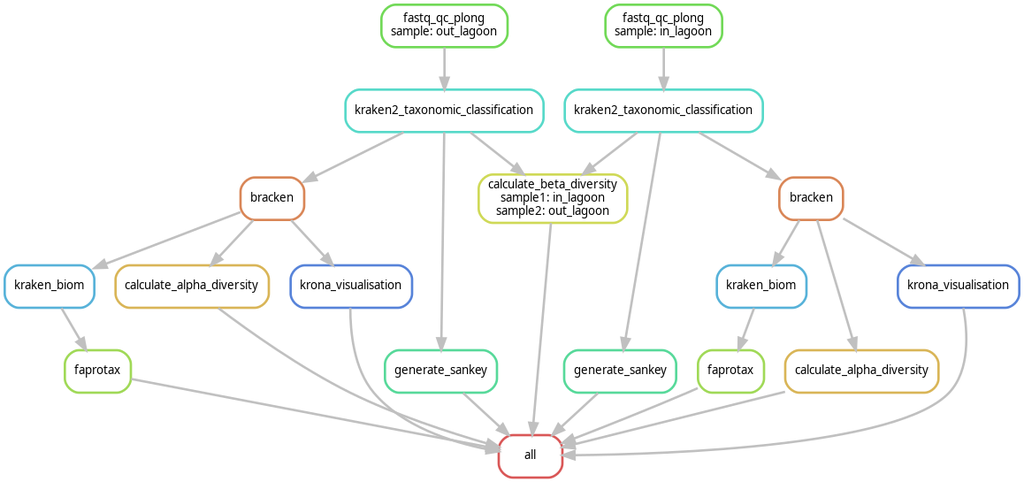

DAG plot of the pipeline

Here is a DAG plot of our pipeline this shows a conceptual representation of a series of activities, basically what our pipeline does.

Our pipeline has 2 files that it puts throguh fastplong, then the 2 files get put through kraken and together get analysed in the beta diversity. Then both files each go through bracken, kraken_biom & krona visualisation. Then they get put through faprotax, calculate alpha diversity and generate sankey. that are all the steps that the pipeline ran for each file.

## 2 april

today i had to write a discussion about the results

# Results + Discussion

#### **Discussion**

Discussie resultaten AFAC-wastewater.

From running our pipeline we received visual results, statistical results and other results. For our visual results, some Krona charts were made, and 2 Sankey charts based on kreports (for now I’m using the bracken Sankey charts due to not having the right charts at this moment). Statistical results included the alpha and beta diversity

**Alpha diversity** **A higher Shannon value signifies a greater level of community diversity** Shannon diversity formula
$$H=−∑[(pi)×log(pi)]$$
Shannon’s diversity: 1.566317721877282 - lagoon in Shannon’s diversity: 1.3645171898188857 - lagoon out

it seems that the water that comes out of the factory into the lagoon has a higher diversity in the microbial community than the lagoon output. This would mean that the digester (closed container utilising anaerobic bacteria to break down organic material and produce methane) does break down some organic material.

| In Lagoon |  |  |
| --- | --- | --- |
| Statistic | Before Filtering | After Filtering |
| Total Reads | 20.242K | 18.042K |
| Mean Length | 1.426K | 1.301K |
| GC Content | 54.45% | 51.67% |
| Out Lagoon |  |  |
| Statistic | Before Filtering | After Filtering |
| Total Reads | 2.41K | 2.16K |
| Mean Length | 1.41K | 1.32K |
| GC Content | 53.65% | 53.16% |

Table 1. Overview of read statistics before and after filtering with Fastplong.

Taxonomic analysis of two samples (lagoon influent and effluent) using Kraken2 reports and Krona piecharts reveals microbial diversity. Both samples primarily consist of cellular organisms, particularly from the domain Bacteria, with a small percentage of Methanobacteriota (archaea).

In the lagoon influent, Bacteria mainly comprises Actinomycetes and Bacillota, with notable species being Streptomyces noursei (20%), Geodermatophilus obscurus (15%), and Pseudonocardia nitrificans (12%), making up 47% of the diversity. In contrast, the lagoon effluent shows a predominance of Actinomycetes, with Mycobacterium kansasii (22%), Thermoanaerobacter sp (20%), and Streptomyces viridochromogenes (9%) representing 51% of the diversity.

**Important notes** In this discussion, the digester has been left out a lot due to a problem with our minION flowcell. Our reads for the digester sample are not of the highest quality.

Our shared doc about the results

#### **Results**

(This results tab was written by all team members and was not only written by me)

After running the pipeline the following results were gathered.

[output not shown]

**Table 1**. Overview of read statistics before and after filtering with Fastplong.

**Taxonomic analysis**

Using Kraken2 reports, Krona piecharts were generated. These piecharts show the microbial diversity of the two samples (lagoon in/lagoon out) (fig.1, fig.2). Visibly most of the operational taxonomic units (OTU’s), of both samples, consist of cellular organisms and a small percentage of transposons. Most of the cellular organisms consist of the domain Bacteria, the rest consists of a small percentage of Methanobacteriota (archaea). The entirety of OTU’s in both samples, in the domain of Bacteria consists of the kingdom Bacillati. In the deeper taxonomic layers, the diversity in OTU’s seems to differ in the two samples.

In the lagoon influent (fig. 1), Bacillati divides into mostly Actinomycetes and a smaller percentage Bacillota. The most common species are Streptomyces noursei (20%), Geodermatophilus obscurus (15%) and Pseudonocardia nitrificans (12%). These 3 species make up 47% of total diversity. 14% is classified as ‘other root’

In the lagoon effluent (fig. 2), at phylum level, there is a visible divide between Actinomycetes and Bacillota, with the majority of OTU’s consisting of Actinomycetes. The most common species are Mycobacterium kansasii (22%), Thermoanaerobacter sp (20%) and Streptomyces viridochromogenes (9%). These 3 species make up 51% of total diversity. 6% is classified as ‘other Root’.

The beta diversity (Bray-Curtis dissimilarity) resulted in a ratio of 0.89.

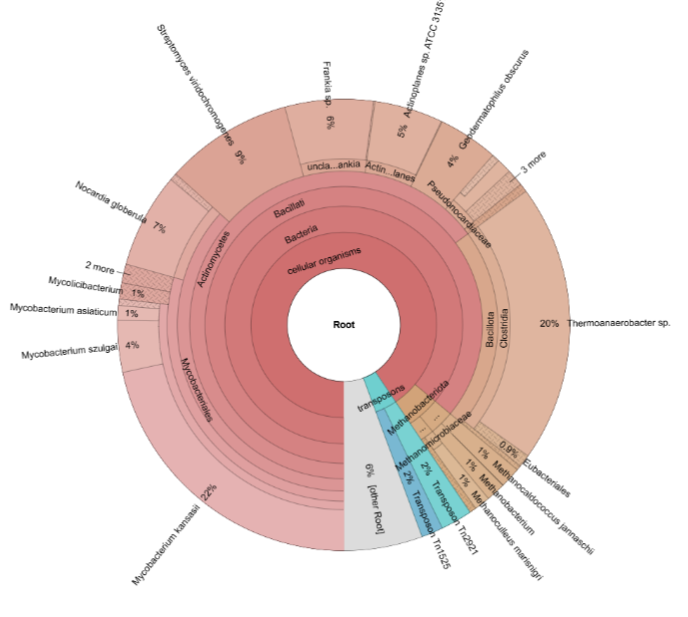

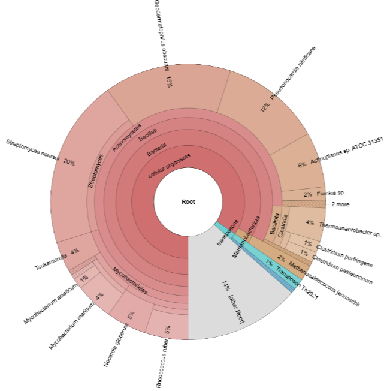

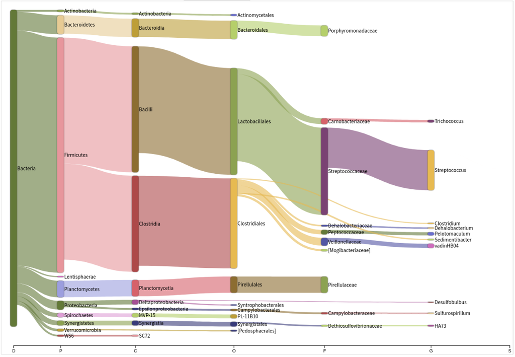

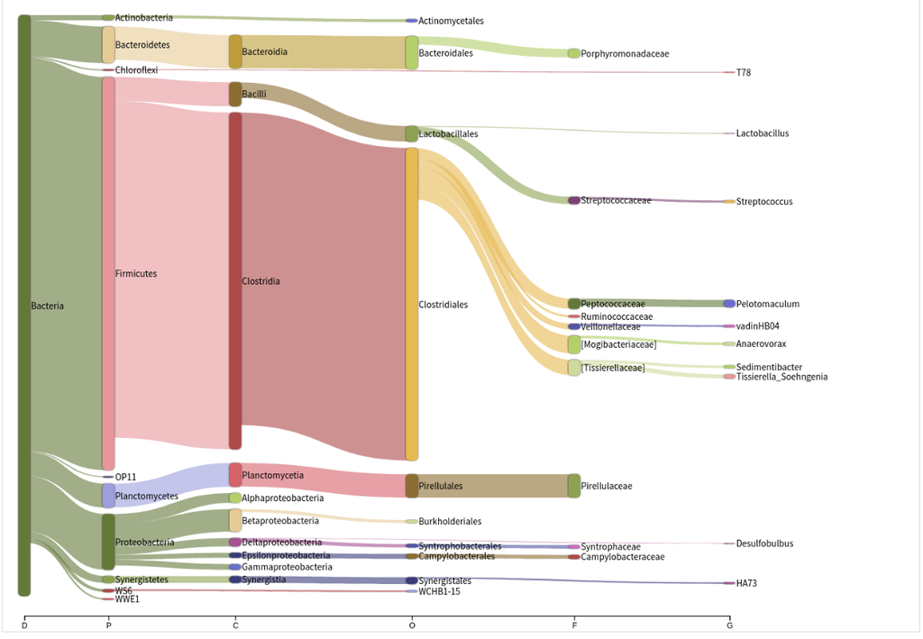

**Functional analysis**

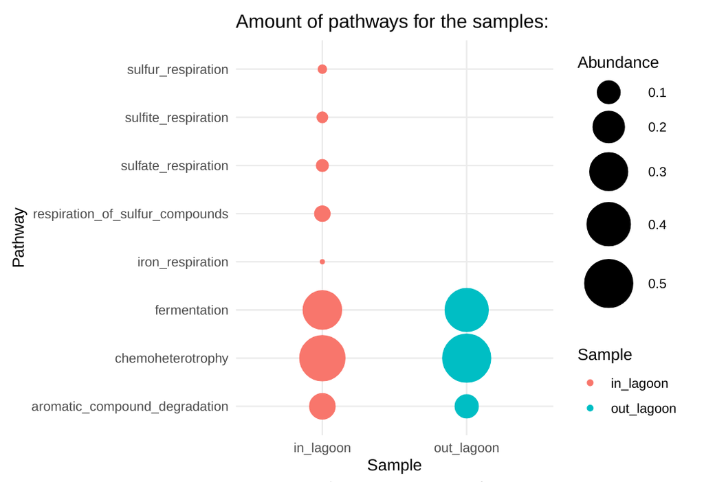

**Fig. 5** Comparison of read abundance signifying the presence of pathways across samples.

Babraham Bioinformatics. n.d. “Babraham Bioinformatics - FastQC A Quality Control Tool for High Throughput Sequence Data.” https://www.bioinformatics.babraham.ac.uk/projects/fastqc/.

Breitwieser, Florian P., and Steven L. Salzberg. 2020. “Pavian: Interactive Analysis of Metagenomics Data for Microbiome Studies and Pathogen Identification.” *Bioinformatics* 36 (4): 1303–4. https://doi.org/10.1093/bioinformatics/btz715.

DeepSeek. 2024. “DeepSeek-R1-Lite-Preview (Version 1.0).” https://www.deepseek.com.

Johns Hopkins University Center for Computational Biology. 2023. *Bracken: Bayesian Reestimation of Abundance with KrakEN* (version 2.8). https://ccb.jhu.edu/software/bracken/index.shtml?t=manual; JHU CCB. https://ccb.jhu.edu/software/bracken/index.shtml?t=manual.

Kaufman, Jeff. 2024. “Krona.” https://github.com/marbl/Krona/wiki.

Lu, Jennifer, and JHU CCB. 2023. “Bracken Sample Output Report.” https://github.com/jenniferlu717/Bracken/blob/master/sample_data/sample_output_bracken.report; GitHub. https://github.com/jenniferlu717/Bracken/blob/master/sample_data/sample_output_bracken.report.

Mangolini, Tania G. 2023. “Awesome_kreport_charts.” *GitHub Repository*. https://github.com/taniagmangolini/awesome_kreport_charts; GitHub. https://github.com/taniagmangolini/awesome_kreport_charts.

Omni Calculator. n.d. “Shannon Index Calculator.” https://www.omnicalculator.com/ecology/shannon-index. https://www.omnicalculator.com/ecology/shannon-index.

Ondov, Brian D., Nicholas H. Bergman, and Adam M. Phillippy. 2011. “Interactive Metagenomic Visualization in a Web Browser.” *BMC Bioinformatics* 12 (1): 385. https://doi.org/10.1186/1471-2105-12-385.

OpenGene. n.d. “Fastplong: A Tool for Preprocessing Nanopore Long Reads.” Accessed October 10, 2023. https://github.com/OpenGene/fastplong.

Oxford Nanopore Technologies. 2023. *16S Barcoding Kit 1-24 (SQK-RAB204)* (version V1.0). https://nanoporetech.com/document/16S-barcoding-1-24; Oxford Nanopore Technologies. https://nanoporetech.com/document/16S-barcoding-1-24.

Wood, D. E., J. Lu, and B. Langmead. 2019. “Improved Metagenomic Analysis with Kraken 2.” *Genome Biology* 20: 257. https://doi.org/10.1186/s13059-019-1891-0.

Wood, Derrick E., Jennifer Lu, and Ben Langmead. 2019a. “Improved Metagenomic Analysis with Kraken 2.” *Genome Biology* 20 (1): 257. https://doi.org/10.1186/s13059-019-1891-0.

———. 2019b. “Kraken 2: Taxonomic Classification System for Metagenomics.” GitHub. https://github.com/DerrickWood/kraken2.